# Seurat PBMCs

## Cluster the cells

Seurat now includes an graph-based clustering approach compared to (Macosko et al.). Importantly, the distance metric which drives the clustering analysis (based on previously identified PCs) remains the same. However, our approach to partioning the cellular distance matrix into clusters has dramatically improved. Our approach was heavily inspired by recent manuscripts which applied graph-based clustering approaches to scRNA-seq data [SNN-Cliq, Xu and Su, Bioinformatics, 2015] and CyTOF data [PhenoGraph, Levine et al., Cell, 2015]. Briefly, these methods embed cells in a graph structure - for example a K-nearest neighbor (KNN) graph, with edges drawn between cells with similar gene expression patterns, and then attempt to partition this graph into highly interconnected ‘quasi-cliques’ or ‘communities’. As in PhenoGraph, we first construct a KNN graph based on the euclidean distance in PCA space, and refine the edge weights between any two cells based on the shared overlap in their local neighborhoods (Jaccard similarity). To cluster the cells, we apply modularity optimization techniques such as the Louvain algorithm (default) or SLM [SLM, Blondel et al., Journal of Statistical Mechanics], to iteratively group cells together, with the goal of optimizing the standard modularity function.

```r
pbmc <- FindNeighbors(pbmc, dims = 1:5)
pbmc <- FindClusters(pbmc, resolution = 0.5)
```

```r
# If you haven't installed UMAP, you can do so via reticulate::py_install(packages =
# 'umap-learn')
pbmc <- RunUMAP(pbmc, dims = 1:5)
pbmc <- RunTSNE(pbmc, dims = 1:5)
```

```r
# note that you can set `label = TRUE` or use the LabelClusters function to help label
# individual clusters
DimPlot(pbmc, reduction = "tsne")

pdf(paste("results/figures/SCT/", name_ana, "_tsne_clusters.pdf"), width = 5, height = 3)
DimPlot(pbmc, reduction = "tsne", group.by = "seurat_clusters")
dev.off()
```

```r
# note that you can set `label = TRUE` or use the LabelClusters function to help label
# individual clusters
DimPlot(pbmc, reduction = "umap")

pdf(paste("results/figures/SCT/", name_ana, "_UMAP_clusters.pdf"), width = 5, height = 3)
DimPlot(pbmc, reduction = "umap", group.by = "seurat_clusters")
dev.off()
```

```r
saveRDS(pbmc, file = paste("/home/flomik/Desktop/Code-PHD/data_COCOMO_txn/SCT/", name_ana, ".rds"))
```

```r
pbmc <- readRDS(paste("/home/flomik/Desktop/Code-PHD/data_COCOMO_txn/SCT/", name_ana, ".rds"))
```

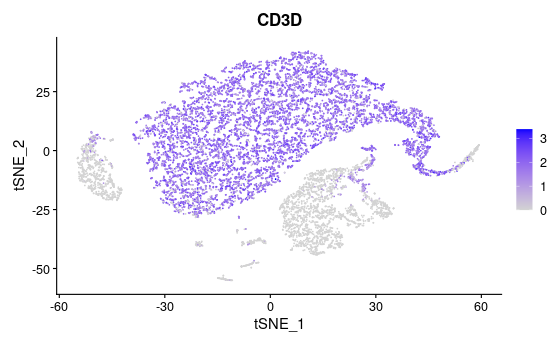

```r
FeaturePlot(pbmc, features = c("CD3D"), reduction = "tsne")
```

```r
## NK cells
### activated = CD69
FeaturePlot(pbmc, features = c("NKG7", "GNLY"), reduction = "tsne")

pdf(paste("results/figures/SCT/", name_ana, "_feature_plot_NK_cells.pdf"))
```

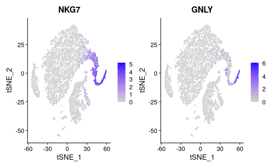

```r
FeaturePlot(pbmc, features = c("NKG7", "GNLY"))
dev.off()
```

```r
## T-CD4 Memory
FeaturePlot(pbmc, features = c("CD4","IL7R", "S100A4"), reduction = "tsne")

pdf(paste("results/figures/SCT/", name_ana, "_feature_plot_CD4_memory.pdf"))
```

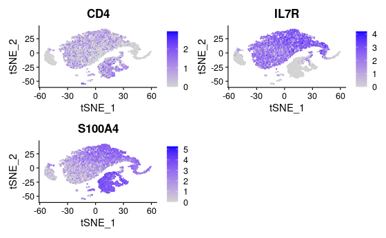

```r
FeaturePlot(pbmc, features = c("CD4","IL7R", "S100A4"))
dev.off()
```

```r
## T-CD4 Naive(CD8-, IL2RA-")
FeaturePlot(pbmc, features = c("IL7R", "CCR7"), reduction = "tsne")

pdf(paste("results/figures/SCT/", name_ana, "_feature_plot_CD4_naive.pdf"))
```

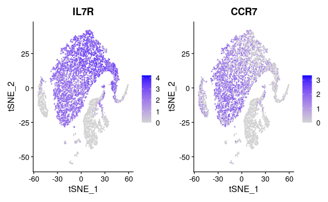

```r
FeaturePlot(pbmc, features = c("CD4","IL7R", "CCR7"))
dev.off()
```

```r
## T-CD8 (CD4-)
FeaturePlot(pbmc, features = c("CD8A", "CD4"), reduction = "tsne")

pdf(paste("results/figures/SCT/", name_ana, "_feature_plot_CD8.pdf"))
```

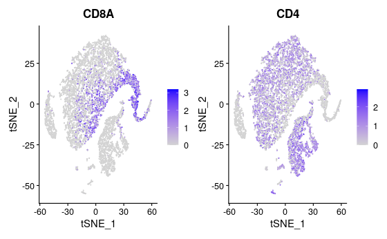

```r
FeaturePlot(pbmc, features = c("CD8A", "CD4"))
dev.off()
```

```r
## B cells
FeaturePlot(pbmc, features = c("CD19", "MS4A1"), reduction = "tsne")

pdf(paste("results/figures/SCT/", name_ana, "_feature_plot_B_cells.pdf"))
```

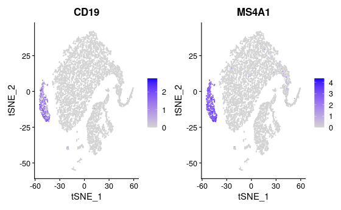

```r
FeaturePlot(pbmc, features = c("CD19", "MS4A1"))
dev.off()
```

```r
## monocytes CD14 (CD19-)
### CD86 = macrophage
FeaturePlot(pbmc, features = c("LYZ", "CD14"), reduction = "tsne")

pdf(paste("results/figures/SCT/", name_ana, "_feature_plot_monocytes_CD14.pdf"))
```

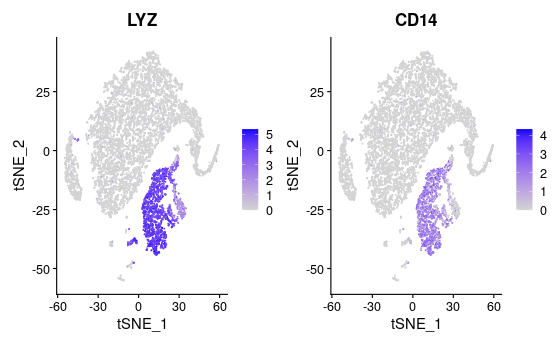

```r
FeaturePlot(pbmc, features = c("LYZ", "CD14"))
dev.off()
```

```r
## monocytes CD16 (CD19-)
FeaturePlot(pbmc, features = c("CD19", "FCGR3A"), reduction = "tsne")

pdf(paste("results/figures/SCT/", name_ana, "_feature_plot_monocytes_CD16.pdf"))
```

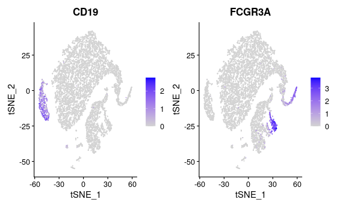

```r
FeaturePlot(pbmc, features = c("CD19", "FCGR3A", "MS4A7"))
dev.off()
```

```r
## dentritic cells (CD14-)
FeaturePlot(pbmc, features = c("FCER1A", "CST3", "CD14"), reduction = "tsne")

pdf(paste("results/figures/SCT/", name_ana, "_feature_plot_dendritic_cells.pdf"))
```

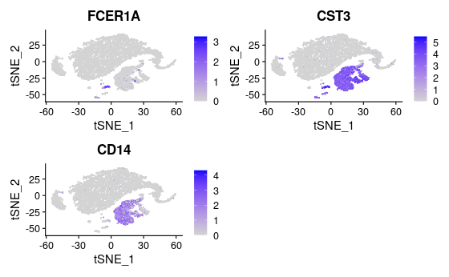

```r
FeaturePlot(pbmc, features = c("FCER1A", "CST3", "CD14"))
dev.off()
```

```r
## platelets
FeaturePlot(pbmc, features = c("PPBP"), reduction = "tsne")

pdf(paste("results/figures/SCT/", name_ana, "_feature_plot_platelet.pdf"))
```

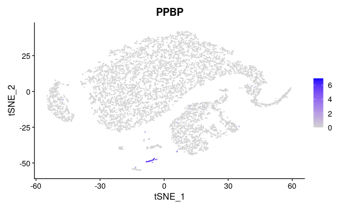

```r
FeaturePlot(pbmc, features = c("PPBP"))
dev.off()
```

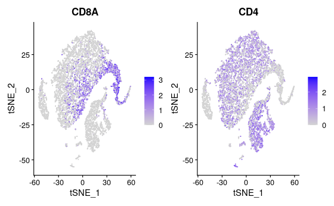

```r
FeaturePlot(pbmc, features = c("CD8A", "CD4"), reduction = "tsne")
```

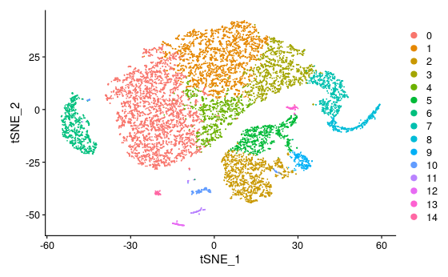

```r
DimPlot(pbmc, reduction = "tsne")
```

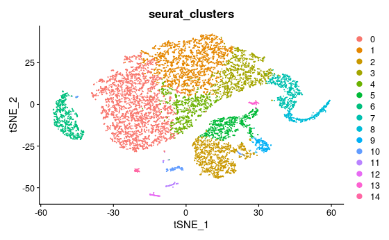

```r
DimPlot(pbmc, reduction = "tsne", group.by = "seurat_clusters")
```

```r
new.cluster.ids <- c("CD4 T", "CD4 T","CD14+ Mono", "CD8 T", "CD8 T",
                    "CD14+ Mono", "B", "CD8 T", "NK",
                    "CD16+ Mono", "DC",  "Platelets", "CD4 T", "CD4 T","CD4 T")
```

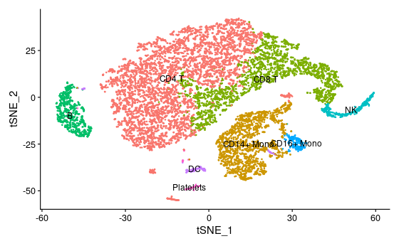

```r
names(new.cluster.ids) <- levels(pbmc)
pbmc <- RenameIdents(pbmc, new.cluster.ids)
DimPlot(pbmc, reduction = "tsne", label = TRUE, pt.size = 0.5) + NoLegend()
```

```r
# note that you can set `label = TRUE` or use the LabelClusters function to help label
# individual clusters
DimPlot(pbmc, reduction = "tsne")

pdf(paste0("results/figures/SCT/", name_ana, "_tsne_clusters_cell_type.pdf"), height = 3, width = 5)
```

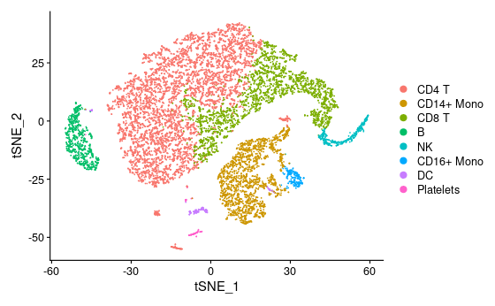

```r
DimPlot(pbmc, reduction = "tsne")
dev.off()
```

```r
# note that you can set `label = TRUE` or use the LabelClusters function to help label
# individual clusters
DimPlot(pbmc, reduction = "umap")

pdf(paste0("results/figures/SCT/", name_ana, "_UMAP_clusters.pdf"), width = 5, height = 3)
```

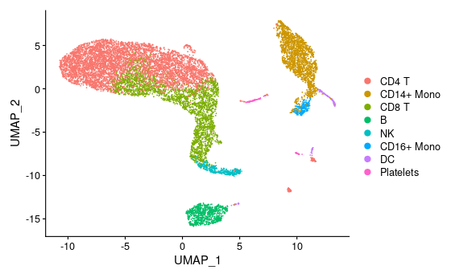

```r
DimPlot(pbmc, reduction = "umap")
dev.off()
```

```r
# find markers for every cluster compared to all remaining cells, report only the positive
# ones
pbmc.markers <- FindAllMarkers(pbmc, only.pos = TRUE, min.pct = 0.25, logfc.threshold = 0.25)
```

[output not shown]

```
NA
```

```r
saveRDS(pbmc, file = paste("/home/flomik/Desktop/Code-PHD/data_COCOMO_txn/SCT/", name_ana, "_with_cell_type.rds"))
```

```r
pbmc <- readRDS(paste("/home/flomik/Desktop/Code-PHD/data_COCOMO_txn/SCT/", name_ana, "_with_cell_type.rds"))
```

```r
library(RColorBrewer)
col <- brewer.pal(9, "Dark2")
col
```

```
[1] "#1B9E77" "#D95F02" "#7570B3" "#E7298A" "#66A61E" "#E6AB02" "#A6761D" "#666666"
```

```r
col <- c(col, "grey")
```

```r
# note that you can set `label = TRUE` or use the LabelClusters function to help label
# individual clusters
DimPlot(pbmc, reduction = "tsne")

pdf(paste0("results/figures/SCT/", name_ana, "_tsne_clusters_cell_type.pdf"), height = 3, width = 5)
```

[figure not shown]

```r
DimPlot(pbmc, reduction = "tsne", cols = col)
dev.off()
```

```r
write.csv(pbmc.markers, paste0("/home/flomik/Desktop/Code-PHD/COCOMO_txn/results/SCT/", name_ana, "_differences_cell_types.csv"))
```

```r
pbmc.markers <- read.csv(paste0("/home/flomik/Desktop/Code-PHD/COCOMO_txn/results/SCT/", name_ana, "_differences_cell_types.csv"))
```

```r
cell_age <- read.csv("/home/flomik/Desktop/Code-PHD/COCOMO_txn/data/senescence/signatures_senescence.csv", sep = ";")
cell_age <- cell_age$gene_symbol
```

```r
sen_2 <- read.delim("/home/flomik/Desktop/Code-PHD/COCOMO_txn/data/senescence/SASP_reactome.tsv")
sen_2$Gene_name <- gsub(".* ", "", sen_2$MoleculeName)

sasap <- sen_2$Gene_name
```

```r
csgene <- read.delim("/home/flomik/Desktop/Code-PHD/COCOMO_txn/data/senescence/csgene_human.txt")
csgene <- csgene$GeneSymb
```

```r
sen <- c(cell_age, sasap, csgene)
```

```r
pbmc.markers_filt <- pbmc.markers[pbmc.markers$p_val_adj < 0.05,]
pbmc.markers_filt <- pbmc.markers[!pbmc.markers$cluster %in% c("Other", "Platelets"),]
pbmc.markers_filt_sasap <- pbmc.markers_filt[pbmc.markers_filt$gene %in% sen,]
pbmc.markers_filt_sasap$SASAP <- ifelse(pbmc.markers_filt_sasap$gene %in% sasap, "SASAP", NA)
pbmc.markers_filt_sasap$cell_age <- ifelse(pbmc.markers_filt_sasap$gene %in% cell_age, "cell_age", NA)
pbmc.markers_filt_sasap$GSGene <- ifelse(pbmc.markers_filt_sasap$gene %in% csgene, "CSGene", NA)
write.csv(pbmc.markers_filt_sasap, paste0("/home/flomik/Desktop/Code-PHD/COCOMO_txn/results/SCT/", name_ana, "_senescence_all_cell_types.csv"))
```

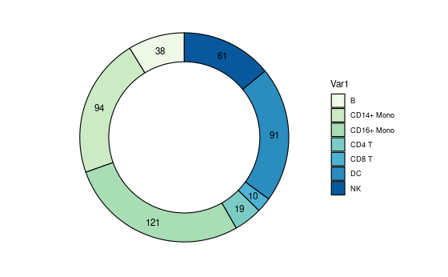

```r
pbmc.markers_filt_sasap_2 <- pbmc.markers_filt[pbmc.markers_filt$gene %in% cell_age,]
pbmc.markers_filt_sasap_2$cluster <- factor(pbmc.markers_filt_sasap_2$cluster)
x <- data.frame(table(pbmc.markers_filt_sasap_2$cluster))

library(ggplot2)
library(dplyr)

# Hole size
hsize <- 3

ggplot(x, aes(x = hsize, y = Freq, fill = Var1)) +
  geom_col(color = "black") +
  geom_text(aes(label = Freq),
             position = position_stack(vjust = 0.5)) +
  coord_polar(theta = "y") +
  scale_fill_brewer(palette = "GnBu") +
  xlim(c(0.2, hsize + 0.5)) +
  theme(panel.background = element_rect(fill = "white"),
        panel.grid = element_blank(),
        axis.title = element_blank(),
        axis.ticks = element_blank(),
        axis.text = element_blank())

ggsave("results/figures/cell_age_cell_types.pdf")
```

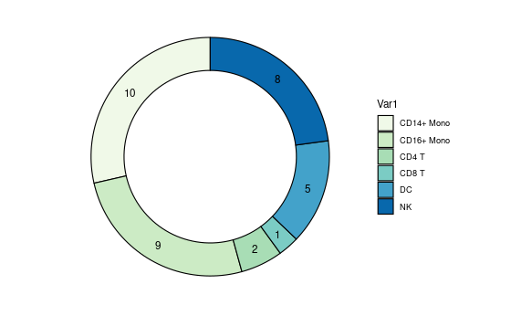

```r
pbmc.markers_filt_sasap_2 <- pbmc.markers_filt[pbmc.markers_filt$gene %in% sasap,]
pbmc.markers_filt_sasap_2$cluster <- factor(pbmc.markers_filt_sasap_2$cluster)
x <- data.frame(table(pbmc.markers_filt_sasap_2$cluster))

library(ggplot2)
library(dplyr)

# Hole size
hsize <- 3

ggplot(x, aes(x = hsize, y = Freq, fill = Var1)) +
  geom_col(color = "black") +
  geom_text(aes(label = Freq),
             position = position_stack(vjust = 0.5)) +
  coord_polar(theta = "y") +
  scale_fill_brewer(palette = "GnBu") +
  xlim(c(0.2, hsize + 0.5)) +
  theme(panel.background = element_rect(fill = "white"),
        panel.grid = element_blank(),
        axis.title = element_blank(),
        axis.ticks = element_blank(),
        axis.text = element_blank())

ggsave("results/figures/sasap_cell_types.pdf")
```

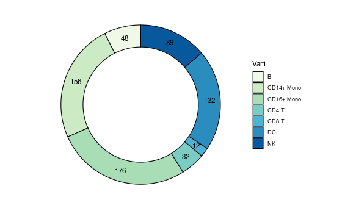

```r
pbmc.markers_filt_sasap$cluster <- factor(pbmc.markers_filt_sasap$cluster)
x <- data.frame(table(pbmc.markers_filt_sasap$cluster))

library(ggplot2)
library(dplyr)

# Hole size
hsize <- 3

ggplot(x, aes(x = hsize, y = Freq, fill = Var1)) +
  geom_col(color = "black") +
  geom_text(aes(label = Freq),
             position = position_stack(vjust = 0.5)) +
  coord_polar(theta = "y") +
  scale_fill_brewer(palette = "GnBu") +
  xlim(c(0.2, hsize + 0.5)) +
  theme(panel.background = element_rect(fill = "white"),
        panel.grid = element_blank(),
        axis.title = element_blank(),
        axis.ticks = element_blank(),
        axis.text = element_blank())

ggsave("results/figures/senescence_cell_types.pdf")
```

```r
dge <- read.csv("/home/flomik/Desktop/Code-PHD/COCOMO_txn/results/LIMMA/model_3_LIMMA_results_olink_with_HC_filt.csv", sep = " ")

#
pbmc.markers_filt_sasap <- pbmc.markers_filt_sasap[pbmc.markers_filt_sasap$gene %in% dge$BIOCHEMICAL,]

write.csv(pbmc.markers_filt_sasap, paste0("/home/flomik/Desktop/Code-PHD/COCOMO_txn/results/SCT/", name_ana, "_senescence_all_cell_types_filt.csv"))
```

```r
pbmc.markers_filt_sasap$cluster <- factor(pbmc.markers_filt_sasap$cluster)
x <- data.frame(table(pbmc.markers_filt_sasap$cluster))
x$name <- "senescence"
col_2 <- c(col[1], col[2], col[6], col[5], col[4], col[7])
```

[output not shown]

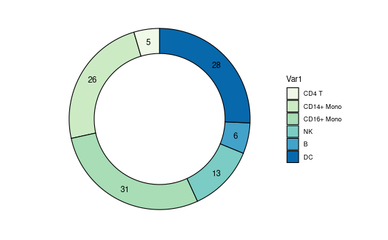

```r
hsize <- 3

ggplot(x, aes(x = hsize, y = Freq, fill = Var1)) +
  geom_col(color = "black") +
  geom_text(aes(label = Freq),
             position = position_stack(vjust = 0.5)) +
  coord_polar(theta = "y") +
  scale_fill_brewer(palette = "GnBu") +
  xlim(c(0.2, hsize + 0.5)) +
  theme(panel.background = element_rect(fill = "white"),
        panel.grid = element_blank(),
        axis.title = element_blank(),
        axis.ticks = element_blank(),
        axis.text = element_blank())

ggsave("results/figures/senescence_cell_types_sign_C1_C2.pdf")
```

## barplot cell age

```r
pbmc.markers_filt_sasap_2 <- pbmc.markers_filt_sasap[pbmc.markers_filt_sasap$gene %in% cell_age,]

write.csv(pbmc.markers_filt_sasap_2, paste0("/home/flomik/Desktop/Code-PHD/COCOMO_txn/results/SCT/", name_ana, "_cell_age_all_cell_types_filt.csv"))

pbmc.markers_filt_sasap_2$cluster <- factor(pbmc.markers_filt_sasap_2$cluster)
```

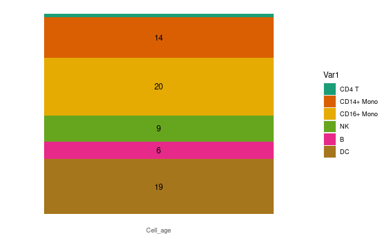

```r
x <- data.frame(table(pbmc.markers_filt_sasap_2$cluster))
x$name <- "Cell_age"
col_2 <- c(col[1], col[2], col[6], col[5], col[4], col[7])
x$Var1 <- factor(x$Var1, levels = c("CD4 T", "CD8 T", "CD14+ Mono", "CD16+ Mono", "NK", "B", "DC"))

# Stacked + percent
ggplot(x, aes(fill=Var1, y=Freq, x=name)) +
    geom_bar(stat="identity")+theme(axis.line=element_blank(),
      axis.ticks=element_blank(),
      axis.text.y = element_blank(),
      axis.title.x=element_blank(),
      axis.title.y=element_blank(),
      panel.background=element_blank(),
      panel.border=element_blank(),
      panel.grid.major=element_blank(),
      panel.grid.minor=element_blank(),
      plot.background=element_blank())+scale_fill_manual(values = col_2)+ geom_text(aes(label=ifelse(Freq >= 5, round(Freq, 0), "")), position=position_stack(vjust=0.5), colour="black")

ggsave("results/figures/cell_age_barplot.pdf", width = 3, height = 4)
```

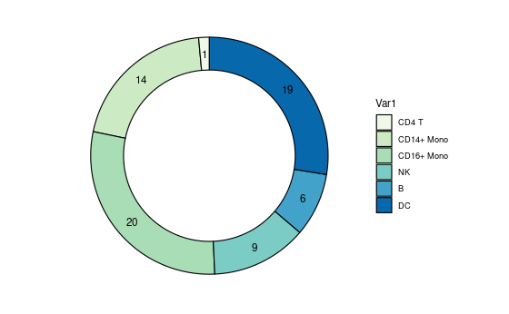

```r
hsize <- 3

ggplot(x, aes(x = hsize, y = Freq, fill = Var1)) +
  geom_col(color = "black") +
  geom_text(aes(label = Freq),
             position = position_stack(vjust = 0.5)) +
  coord_polar(theta = "y") +
  scale_fill_brewer(palette = "GnBu") +
  xlim(c(0.2, hsize + 0.5)) +
  theme(panel.background = element_rect(fill = "white"),
        panel.grid = element_blank(),
        axis.title = element_blank(),
        axis.ticks = element_blank(),
        axis.text = element_blank())

ggsave("results/figures/cell_age_cell_types_sign_C1_C2.pdf")
```

```r
pbmc.markers_filt_sasap_2 <- pbmc.markers_filt_sasap[pbmc.markers_filt_sasap$gene %in% sasap,]

write.csv(pbmc.markers_filt_sasap_2, paste0("/home/flomik/Desktop/Code-PHD/COCOMO_txn/results/SCT/", name_ana, "_SASAP_all_cell_types_filt.csv"))
pbmc.markers_filt_sasap_2$cluster <- factor(pbmc.markers_filt_sasap_2$cluster)
x <- data.frame(table(pbmc.markers_filt_sasap_2$cluster))
```

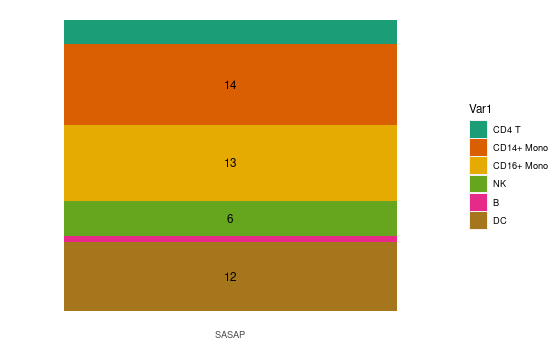

```r
x <- data.frame(table(pbmc.markers_filt_sasap_2$cluster))
x$name <- "SASAP"
col_2 <- c(col[1], col[2], col[6], col[5], col[4], col[7])
x$Var1 <- factor(x$Var1, levels = c("CD4 T", "CD8 T", "CD14+ Mono", "CD16+ Mono", "NK", "B", "DC"))

# Stacked + percent
ggplot(x, aes(fill=Var1, y=Freq, x=name)) +
    geom_bar(stat="identity")+theme(axis.line=element_blank(),
      axis.ticks=element_blank(),
      axis.text.y = element_blank(),
      axis.title.x=element_blank(),
      axis.title.y=element_blank(),
      panel.background=element_blank(),
      panel.border=element_blank(),
      panel.grid.major=element_blank(),
      panel.grid.minor=element_blank(),
      plot.background=element_blank())+scale_fill_manual(values = col_2)+ geom_text(aes(label=ifelse(Freq >= 5, round(Freq, 0), "")), position=position_stack(vjust=0.5), colour="black")

ggsave("results/figures/SASAP_barplot.pdf", width = 3, height = 4)
```

[figure not shown]

```r
hsize <- 3

ggplot(x, aes(x = hsize, y = Freq, fill = Var1)) +
  geom_col(color = "black") +
  geom_text(aes(label = Freq),
             position = position_stack(vjust = 0.5)) +
  coord_polar(theta = "y") +
  scale_fill_brewer(palette = "GnBu") +
  xlim(c(0.2, hsize + 0.5)) +
  theme(panel.background = element_rect(fill = "white"),
        panel.grid = element_blank(),
        axis.title = element_blank(),
        axis.ticks = element_blank(),
        axis.text = element_blank())

ggsave("results/figures/sasap_cell_types_sign_C1_C2.pdf")
```

```r
pbmc.markers_filt_sasap$cluster <- factor(pbmc.markers_filt_sasap$cluster)
```

```r
driver_genes <- c("PLPBP", "TXLNA", "LATS1", "TBCB", "GGCT")

pbmc.markers_filt_driver <- pbmc.markers_filt[pbmc.markers_filt$gene %in% driver_genes,]

driver_genes[driver_genes %in% sen]
```

```
[1] "GGCT"
```

```r
pbmc.markers_filt_sasap <- pbmc.markers_filt_sasap[abs(pbmc.markers_filt_sasap$avg_log2FC) > 1,]

pbmc.markers_filt_sasap <- pbmc.markers_filt_sasap[order(pbmc.markers_filt_sasap$avg_log2FC, decreasing = TRUE),]
pbmc.markers_filt_sasap$rank <- 1:21
```

```r
write.csv(pbmc.markers_filt_sasap, paste0("/home/flomik/Desktop/Code-PHD/COCOMO_txn/results/SCT/", name_ana, "_top_10_markers.csv"))
```

```r
# How many cells are in each cluster
prop <- data.frame(table(Idents(pbmc)))
write.csv(prop, paste0("/home/flomik/Desktop/Code-PHD/COCOMO_txn/results/SCT/", name_ana, "_numbers_cell_types.csv"))
```

```r
library(ggplot2)
library("gridExtra")
```

```r
library(viridis)
col <- c("lightgrey", viridis(7))
```

```r
x <- FeaturePlot(pbmc, features = "EPSTI1", reduction = "tsne", cols = col)
ggplot2::ggsave(paste0("/home/flomik/Desktop/Code-PHD/COCOMO_txn/results/figures/SCT/gene_expression/EPSTI1_feature_plot.pdf"), height = 3, width = 5)
```

```r
list_x <- list()
list_y <- list()
a <- 1

for (i in pbmc.markers_filt_sasap$gene) {
  print(i)
  x <- FeaturePlot(pbmc, features = i, reduction = "tsne", cols = col)
  list_x[[a]] <- x
  ggplot2::ggsave(paste0("/home/flomik/Desktop/Code-PHD/COCOMO_txn/results/figures/SCT/gene_expression/", name_ana, "_feature_plot_", i, ".pdf"), height = 3, width = 3.5)
  y <- VlnPlot(object = pbmc, features = i, cols = col)
  list_y[[a]] <- y
  #ggplot2::ggsave(paste0("/home/flomik/Desktop/Code-PHD/COCOMO_txn/results/figures/SCT/gene_expression/", name_ana, "_violon_plot_", i, ".pdf"), height = 3, width = 6)

  a <- a + 1
  #pdf(paste0("/home/flomik/Desktop/Code-PHD/COCOMO_txn/results/figures/SCT/gene_expression/", name_ana, "feature_violon_plot_", i, ".pdf"), height = 3, width = 10)
  #grid.arrange(x, y, ncol = 2, nrow = 1)
  #dev.off()

}
```

```
[1] "CTSD"
[1] "CXCL8"
[1] "ASAH1"
[1] "CD36"
[1] "NPC2"
[1] "PGD"
[1] "LGALS9"
[1] "IGFBP7"
[1] "ASAH1"
[1] "TNFSF13"
[1] "GAPDH"
[1] "NPC2"
[1] "CPPED1"
[1] "LGALS9"
[1] "RRAS"
[1] "GAPDH"
[1] "LGALS9"
[1] "CPPED1"
[1] "PLEKHO1"
[1] "EIF4EBP1"
[1] "HBEGF"
```

```r
pdf(paste0("/home/flomik/Desktop/Code-PHD/COCOMO_txn/results/figures/SCT/tsne_top_10_genes.pdf"), height = 9, width = 26)
FeaturePlot(pbmc, features = pbmc.markers_filt_sasap$gene[1:10], reduction = "tsne", keep.scale = "feature", ncol = 5, coord.fixed = TRUE, repel = TRUE)
dev.off()
```

```r
levels(pbmc@active.ident) <- rev(c("CD8 T","CD4 T", "CD14+ Mono", "CD16+ Mono", "DC", "NK", "B", "Platelets", "Others"))
```

```r
col <- brewer.pal(10, "Set3")
```

```r
pdf(paste0("/home/flomik/Desktop/Code-PHD/COCOMO_txn/results/figures/SCT/violin_plot_top_10_genes.pdf"), height = 5, width = 12)
VlnPlot(object = pbmc, features = pbmc.markers_filt_sasap$gene[1:10], stack = TRUE , idents = c("CD8 T","CD4 T", "CD14+ Mono", "CD16+ Mono", "DC", "NK", "B"), same.y.lims = TRUE, cols = col, pt.size = 1)
dev.off()
```

```r
x <- unique(pbmc@active.ident)
```

```r
col2 <- brewer.pal(15, "Set2")
```

[figure not shown]

```r
y
ggplot2::ggsave(paste0("/home/flomik/Desktop/Code-PHD/COCOMO_txn/results/figures/SCT/", name_ana, "_violon_plot_global.pdf"), width = 10)
```